# Emissions Levels and Life Satisfaction

## Evaluating the Effect of Emissions on Happiness in Germany

[View on GitHub](https://github.com/SarahU3/Climate-Happiness) [Download .zip](https://github.com/SarahU3/Climate-Happiness/zipball/master) [Download .tar.gz](https://github.com/SarahU3/Climate-Happiness/tarball/master)

A research project by [Katie Levesque](https://github.com/Katie-Levesque), [Sarah Unbehaun](https://github.com/SarahU3) and [Meerim Ruslanova](https://github.com/mruslanova)

### Introduction

Climate change is undoubtedly a global problem, but this fact means it is also a classic tragedy of the commons. No country wants to put itself at an economic disadvantage by restricting the use of cheap fossil fuels so all continue to emit, deteriorating the “commons” of the Earth’s protective atmosphere. This can make it difficult to get citizens to identify with the problem and take responsibility; people will more likely act when something affects them individually. On the other hand, some also argue that “green growth,” i.e. economic growth with strict environmental regulations, has positive effects both economically and on individual weel-being. In this paper we want to explore these arguments: in an environmentally-conscious country like Germany, how much do people feel, consciously or unconsciously, the effects of green house gas emissions? More specifically, do emissions affect their reported well-being or life satisfaction?

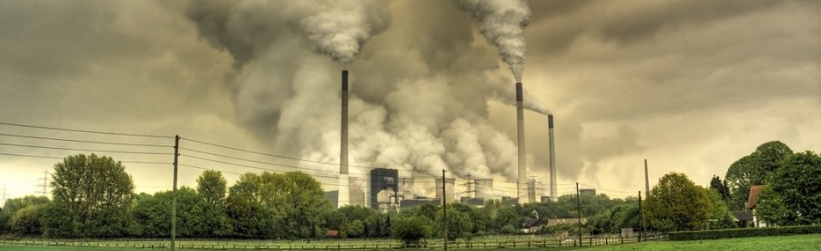

### Our Research

Germany is a leader in protecting the environment while also having a long history as an industrial power and coal producer. On one hand, its energy transition (*Energiewende*) is considered one of the most ambitious climate policy projects in the world. On the other hand, it has struggled with appropriate incentives, a drop in oil prices and how to transform the transportation sector, not to mention coal’s continued role as a cheap and reliable fuel. Germany therefore still does emit large amounts of green house gases. We will look at greenhouse gas emissions data by federal state (*Bundesland*) and compare that with life satisfaction data to examine our first hypothesis:

> *H1: Bundeslaender with higher emissions will have lower reported levels of life satisfaction.*

On the other hand, it may not be the emissions themselves that affect people’s life satisfaction. People who are more concerned about the environment would be more concerned with emissions and may feel less satisfied with life than those who are less concerned about the environment. Therefore our second hypothesis is:

> *H2: Reported individual concerns with the environment are, likewise, negatively reflected in the life satisfaction.*

Controlling for state- and time-fixed effects, we anticipate the following effects as a result of our model:

- CO2 Emissions Per Capita (-)
- CO2 Emissions Per Square KM (-)
- Concern About the Environment (-)
- Age (-)
- Monthly Income/Employment (+)
- Having a partner (+)
- Gender (no diff.)

### Data

For the purpose of our research, the following data has been collected:

- The **individual-level data** on individual characteristics and survey data is provided by:
  - The German Socio-Economic Panel Data ([GSOEP](https://paneldata.org/)), conducted by the German Institute for Economic Research (DIW)
- The **state-level data** on emissions levels, state size, and population is gathered from four web-based sources:
  - [Statista.com](http://de.statista.com/statistik/daten/studie/258063/umfrage/kohlendioxid-emissionen-je-einwohner-in-nordrhein-westfalen/)
  - Environmental-Economic Accounting of the Bundeslaender [UGRdL](http://www.ugrdl.de/tab34.htm)
  - Agency for Renewable Agency of North Rhine-Westphalia [AfEE](http://www.foederal-erneuerbar.de/landesinfo/bundesland/NRW/kategorie/wirtschaft/ordnung/2010)
  - [Federal Statistical Office and Statistical Offices of the Bundeslaender](http://www.statistik-portal.de/Statistik-Portal/en/en_jb01_jahrtab1.asp)
  - [Laenderarbeitskreis](http://www.lak-energiebilanzen.de/dseiten/co2BilanzenAktuelleErgebnisse.cfm)

### What Determines Overall Satisfaction?

Using the means of each state, the scatterplots below shows the correlation between our variables of interest and overall happiness levels.

#### Correlation of Age and Life Satisfaction

Age seems to be very slightly positively correlated, though the majority of observations in the middle show a fairly flat trend.

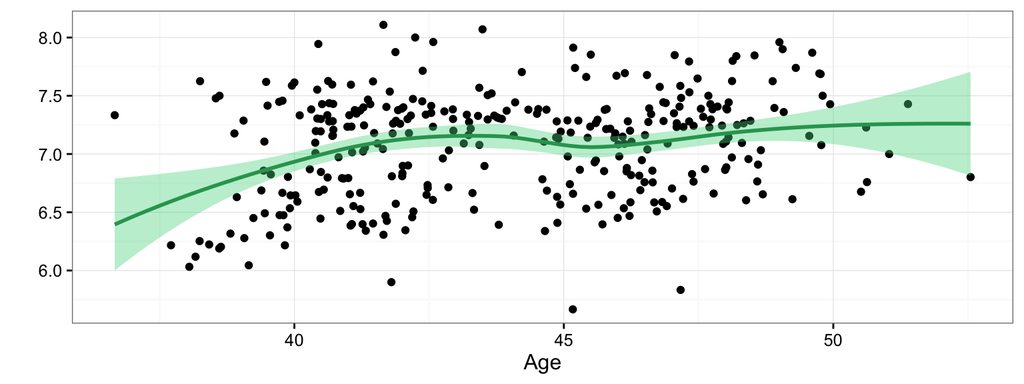

#### Correlation of Gross Monthly Income and Life Satisfaction

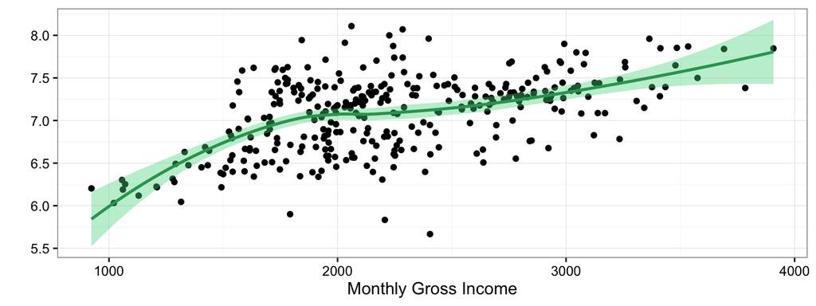

#### Correlation of Emissions and Life Satisfaction

Comparing the state-level emissions data with life satisfaction, it seems that emissions, whether measured per capita or per square kilometer, both appear almost flat, though with an interesting peak in lower emissions per capita.

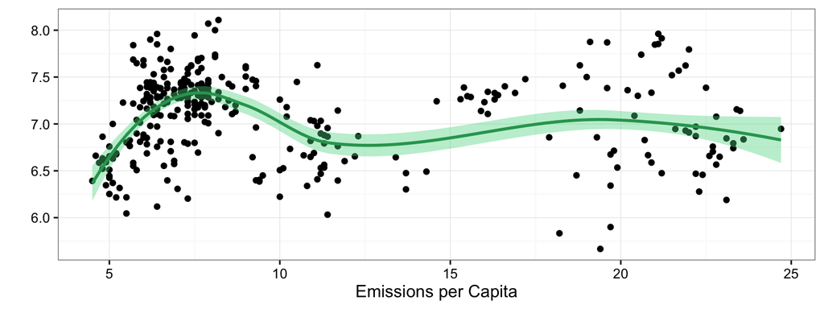

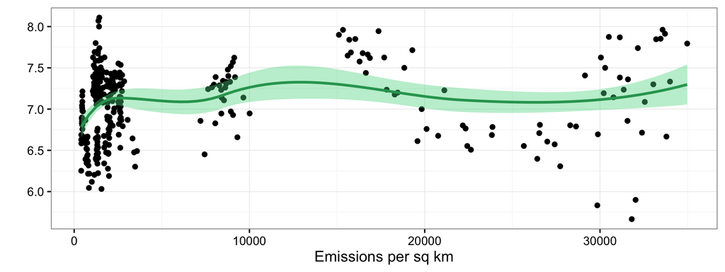

#### Correlation of Concern for the Environment and Life Satisfaction

Life satisfaction appears to be negatively correlated with environmental concern, indicating that the more concerned a respondent is about environmental conditions, the lower the overall happiness of respondents, though the relationship is weak.

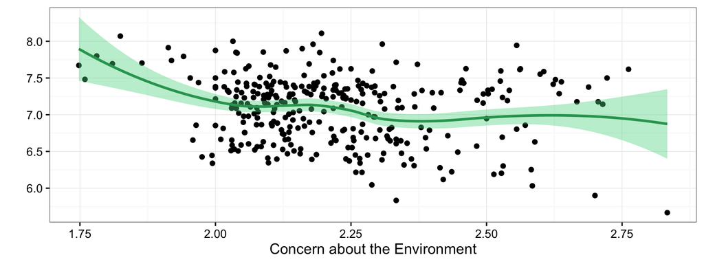

#### Overview of Emissions by State

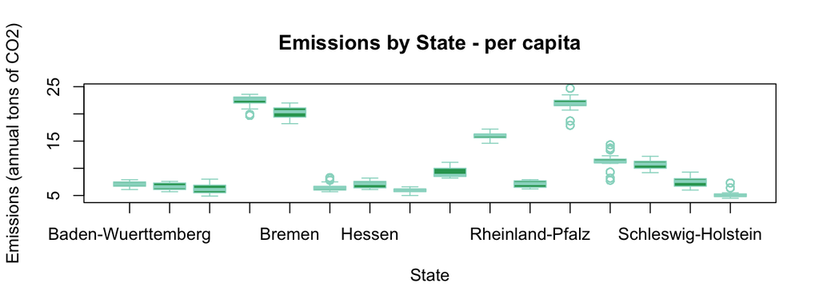

When measured in square kilometers, the three city-states of Bremen, Berlin, and Hamburg are unsurprisingly the highest due to their small land area, not to mention relatively dense populations. Saarland is also geographically small, which means that Nordrhein-Westfalen is the only standout in this measure as a state with both a large land area and high emissions.

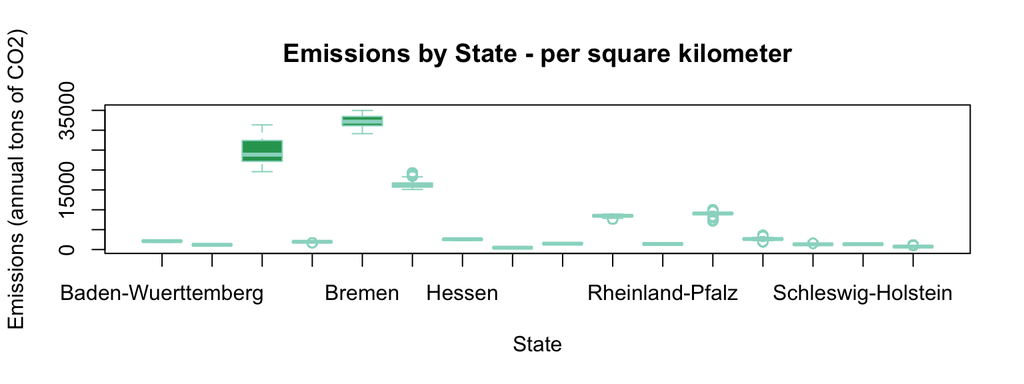

### Results

In our data, the potential negative impacts on happiness associated with various configurations of emission levels was nearly non-existent (despite being statistically significant) when we controlled for state-level and individual characteristics. We approached the problem of estimating the reduction in satisfaction by examining a number of regressions based on life-satisfaction that include a variety of socio-economic data to justify a person’s stated level of life satisfaction on a subjective 1-10 scale.

| Variable | Coefficient direction and strength | Expected direction |
| --- | --- | --- |
| Total Emissions | - | - |
| Emissions per Capita | - | - |
| Emissions per Sq. KM | - | - |
| Concern for the Environment | - | - |
| Age | – | - |
| Monthly Income | + | + |
| Employment | ++ | + |
| Having a partner | ++ | + |
| Gender (no diff.) | + | ~ |

### Conclusions

Multilevel Coefficient Models show that the variables of interest, state-level emissions and environmental worries, demonstrate minimal negative impact on life satisfaction, despite being statistically significant. These findings might be explained by the fact that, while some Bundeslaender do emit large volumes of GHG per square kilometer, they are still relatively low compared to other energy-intensive economies like China. Thus, the impact of these emissions is neither readily tangible, nor directly relevant for the German population in terms of extreme natural disasters and environmental changes. Even the recent appearances of global climate change in the form of heat waves and extreme weather are usually common for the whole country, distorting the direct impact of the state-specific climate performance on its residents’ well-being.

Moreover, controlling for the socio-economic factors confirms that being employed and having a partner substantially increases one’s life satisfaction, while ageing does the opposite, albeit negligibly for every year. Income also has a minimal positive effect, as well as being a woman.

In short, this research supports some of the previous literature when looked at in terms of statistical significance, but in terms of social significance, they indicate that emissions do not seem to play a large role in determining their life satisfaction. While citizens might be enjoying the benefits of green growth in more abstract ways, they do not feel the direct impacts strongly in comparison to other factors affecting their life satisfaction.

### Sources

Blanchflower, David G., and Andrew Oswald. 2007. “Is Well-Being U-Shaped over the Life Cycle?” no. 12935. National Bureau of Economic Research.

Bliese, Paul. 2013. “Multilevel Models in R,” 1–88. [link](https://cran.r-project.org/doc/contrib/Bliese_Multilevel.pdf).

Brereton, Finbarr, J Peter Clinch, and Susana Ferreira. 2008. “Happiness, Geography and the Environment.” *Ecological Economics* 65 (2). Elsevier: 386–96.

Conceicao, Pedro, and Romina Bandura. n.d. “Measuring Subjective Wellbeing: A Summary Review of the Literature.” Office of Development Studies, United Nations Development Programme (UNDP). [link](http://web.undp.org/developmentstudies/docs/subjective_wellbeing_conceicao_bandura.pdf).

Cunado, Juncal, and Fernando Perez de Gracia. 2013. “Environment and Happiness: New Evidence for Spain.” *Social Indicators Research* 112 (3). Springer: 549–67.

Easterlin, Richard. 1974. “Does Economic Growth Improve the Human Lot? Some Empirical Evidence.” In *Nations and Households in Economic Growth: Essays in Honour of Moses Abramovit*, edited by P. David and M. Reder. Academic Press.

Ferreira, Susana, and Mirko Moro. 2010. “On the Use of Subjective Well-Being Data for Environmental Valuation.” *Environmental and Resource Economics* 46 (3). Springer: 249–73.

Ferrer-i-Carbonell, Ada, and John M Gowdy. 2007. “Environmental Degradation and Happiness.” *Ecological Economics* 60 (3). Elsevier: 509–16.

Goetzke, Frank, and Tilmann Rave. 2015. “Regional Air Quality and Happiness in Germany.” *International Regional Science Review* 38 (4). SAGE Publications: 437–51.

Helliwell, John F. 2003. “How’s Life? Combining Individual and National Variables to Explain Subjective Well-Being.” *Economic Modelling* 20 (2): 331–60.

Jakob, O. Edenhofer, M. 2014. “Green Growth, Degrowth and the Commons.” *Oxford Review of Economic Policy* 30: 447–68.

Luechinger, Simon. 2009. “Valuing Air Quality Using the Life Satisfaction Approach.” *The Economic Journal* 119 (536). Wiley Online Library: 482–515.

MacKerron, George, and Susana Mourato. 2009. “Life Satisfaction and Air Quality in London.” *Ecological Economics* 68 (5). Elsevier: 1441–53.

Menz, Tobias, and Heinz Welsch. 2010. “Population Aging and Environmental Preferences in OECD Countries: The Case of Air Pollution.” *Ecological Economics* 69 (12). Elsevier: 2582–9.

OECD. 2011. “Towards Green Growth.” *OECD Green Growth Studies*. OECD Publishing. doi: [link](http://dx.doi.org/10.1787/9789264111318-en).

———. 2014. “Green Growth Indicators 2014.” *OECD Green Growth Studies*. OECD Publishing. 20 doi: [link](http://dx.doi.org/10.1787/9789264202030-en).

Rehdanz, Katrin, and David Maddison. 2008. “Local Environmental Quality and Life-Satisfaction in Germany.” *Ecological Economics* 64 (4). Elsevier: 787–97.

Rivers, Douglas, and Quang H Vuong. 1988. “Limited Information Estimators and Exogeneity Tests for Simultaneous Probit Models.” *Journal of Econometrics* 39 (3). Elsevier: 347–66.

Sekulova, Filka. 2013. “On the Economics of Happiness and Climate Change.” PhD thesis, Universitat Autonoma de Barcelona & Institut de Ciencia i Tecnologia Ambientals. [link](https://ddd.uab.cat/pub/tesis/2013/hdl_10803_120213/fs1de1.pdf).

Van Praag, Bernard, and Barbara E Baarsma. 2005. “Using Happiness Surveys to Value Intangibles: The Case of Airport Noise.” *The Economic Journal* 115 (500). Wiley Online Library: 224–46.

Welsch, Heinz. 2002. “Preferences over Prosperity and Pollution: Environmental Valuation Based on Happiness Surveys.” *Kyklos* 55 (4). Wiley Online Library: 473–94.

———. 2006. “Environment and Happiness: Valuation of Air Pollution Using Life Satisfaction Data.” *Ecological Economics* 58 (4). Elsevier: 801–13.